# Task 3

Jenna Wisniewski

11/4/2020

## Read in the Urchin Data

```r
urchins <- read_csv(here("data", "urchins.csv")) %>%
  clean_names()
```

## Section 1- Size Comparison: Purple and Red Urchins

### Exploratory Data Visualization

In this section I look at the distribution of sizes between red and purple urchins using two types of graphs.

#### Create a Faceted Histogram

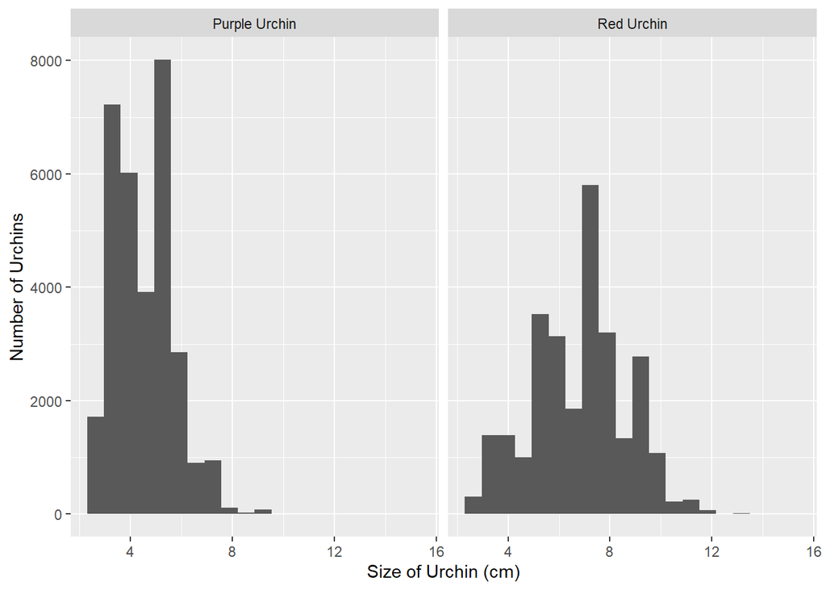

```r
ggplot(data = urchins, aes(x = size))+
  geom_histogram(bins = 20) +
  facet_wrap(~common_name)+
   labs(x = "Size of Urchin (cm)",
       y = "Number of Urchins")
```

#### Create a Boxplot

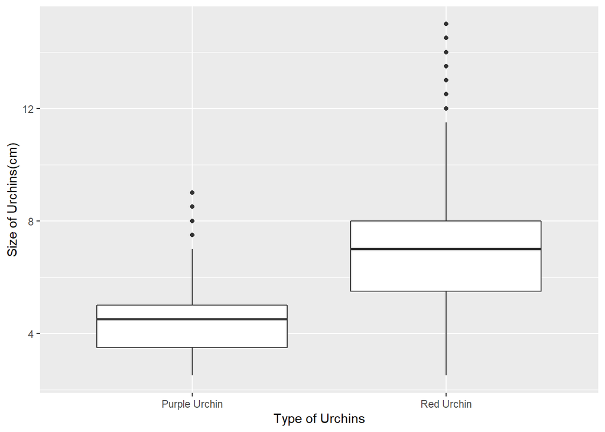

```r
ggplot(data = urchins, aes(x = common_name, y = size))+
  geom_boxplot() +
   labs(x = "Type of Urchins",
       y = "Size of Urchins(cm)")
```

### Descriptive Statistics Table

In this section I will create and look at the statistics of for both red urchin and purple urchin populations (mean, median, standard deviation, n)

```r
urchin_stats <- urchins %>%
  group_by(common_name) %>%
  summarize(
    mean_size = mean(size),
    median_size = median(size),
    sd_size = sd(size),
    n = n())



urchin_stats
```

```
## # A tibble: 2 x 5
##   common_name   mean_size median_size sd_size     n
##   <chr>             <dbl>       <dbl>   <dbl> <int>
## 1 Purple Urchin      4.47         4.5    1.18 31805
## 2 Red Urchin         6.78         7      1.89 27408
```

### Overall Takeaways

#### Calculations

```r
#Actual difference in means between red and purple urchins
6.776489 - 4.469797
```

```
## [1] 2.306692
```

```r
#Percent difference in means between red and purple urchins
(6.776489 - 4.469797) / (5.623143)*100
```

```
## [1] 41.0214
```

The red urchin has both a larger mean size (~ 2.3cm larger or 41.02% difference) and a larger median size than the purple urchin. The red urchin also has a larger standard deviation (~0.7 larger) meaning that the sample data was more spread about from the mean in the red urchin sample, while the purple urchin sample was grouped closer to the mean. The red urchin data appears to have a more normal distribution when it is graphed, while the purple urchin has two data spikes instead of the data being centered around one clear median.

## Section 2- Exploring Purple Urchin Counts by Site and Year

### Data Wrangling

In this section I will create a subset of the data that

-filters observations for only purple urchins

-Converts the date to class “Date”

-Create a new column that only contains the year

-Create a new column that contains the full name of each of the five sites

```r
 purple_urchins <- urchins %>%
  filter(common_name == "Purple Urchin") %>%
  mutate(date = mdy(date)) %>%
  mutate(year = year(date)) %>%
  mutate(site_full = case_when(
site == "NAPL" ~ "Naples Reef",
site == "AQUE" ~ "Arroyo Quemado Reef",
site == "CARP" ~ "Carpinteria Reef",
site == "MOHK" ~ "Mohawk Reef",
site == "IVEE" ~ "Isla Vista Reed"
))
```

### Descriptive Statistics Table

In this section I will create a table containing the total number of purple urchins observed by site and year.

```r
urchin_count <- purple_urchins %>%
  select("year", "site_full") %>%
   count(year, site_full)

urchin_count
```

```
## # A tibble: 61 x 3
##     year site_full               n
##    <dbl> <chr>               <int>
##  1  2008 Arroyo Quemado Reef    67
##  2  2008 Carpinteria Reef      265
##  3  2008 Mohawk Reef           294
##  4  2008 Naples Reef           246
##  5  2009 Arroyo Quemado Reef   926
##  6  2009 Carpinteria Reef     1315
##  7  2009 Mohawk Reef          1344
##  8  2009 Naples Reef          1064
##  9  2010 Arroyo Quemado Reef   921
## 10  2010 Carpinteria Reef      930
## # ... with 51 more rows
```

### Make an Explanantory Graph

In this section I will create exploratory graphs of the purple urchins recorded at each site over time for the years included in the study.

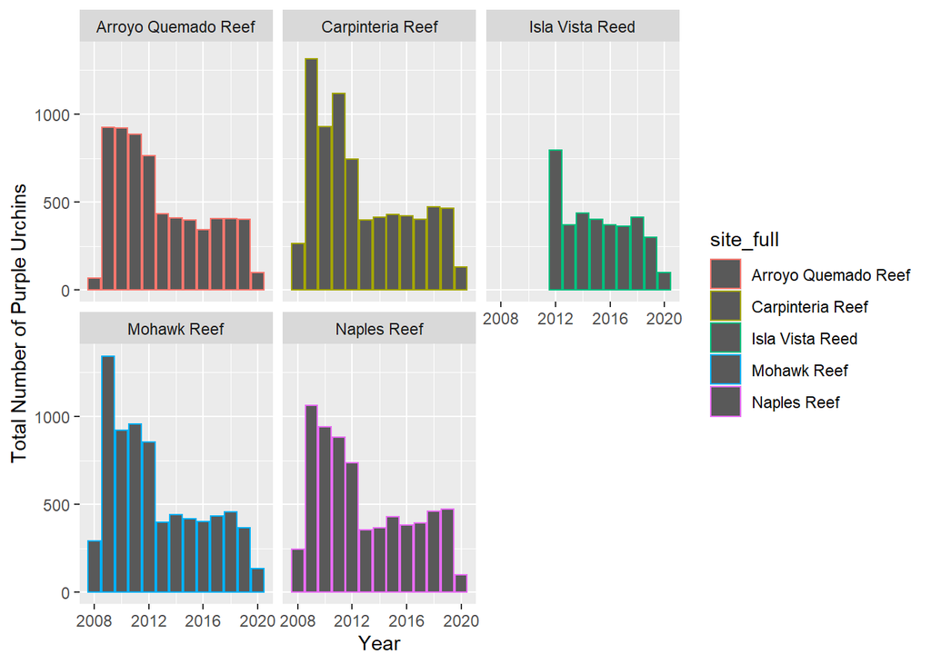

```r
ggplot(data = urchin_count, aes(x = year, y = n))+
  geom_col(aes(color = site_full))+
  facet_wrap(~site_full)+
  labs(x = "Year",
       y = "Total Number of Purple Urchins")
```